# (Explanatory Analysis on Ford GoBike System)

## by (Ohwavworua Obakpororo Christopher)

## Investigation Overview

This presentation will be focused on an explanatory analysis on the following insights;

1. Gender patronage of the Fordgobike services
2. The ride volume per weekday
3. The effect of age(grouped into decades) in the ride duration
4. The ride duration for each usertype per weekday.

## Dataset Overview

The dataset includes information about individual rides made in a bike-sharing system covering the greater San Francisco Bay area. It covers the detais of 174202 rides observed in 15 different columns. These details include the duration of rides in minutes, the start and end time of rides, the age of riders, the sex of the riders and the user type of the riders.

## Gender patronage of the Fordgobike services

The gender of each observation was recorded in the dataset. They were categorizes into three different types namely the male, female and others. The plot below reveals that within the month of february, the Fordgobike services recorded 129982 male patronage, 40606 female patronage and 3614 patronage for others.

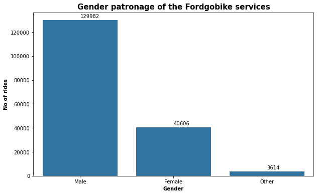

## The ride volume per weekday

The height of the bar plot below shows the different number of rides that were completed on each day of the week. The plot reveals that thursdays recorded the most rides for the week while the weekends i.e saturdays and sundays recorded the least number of rides taken.

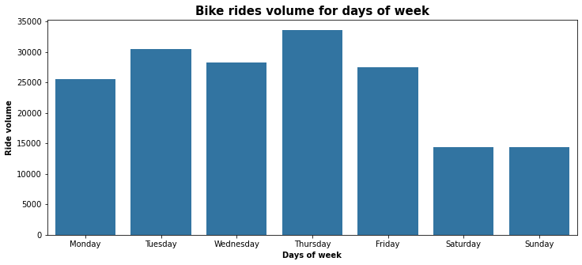

## The effect of age(grouped into decades) in the ride duration

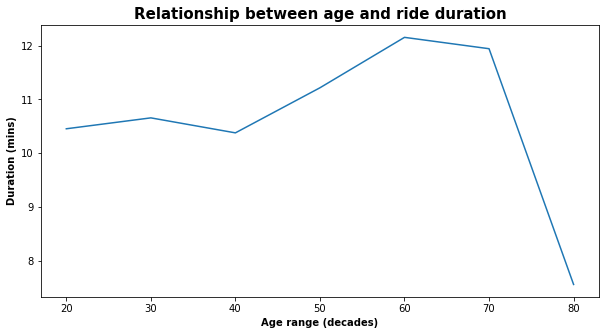

## The ride duration for each usertype per weekday

The chart below shows the mean duration for each user type per weekday. It reveals that subscribers have an almost even mean duration for all weekdays. While customers on the other hand, recorded the highest mean ride duration on sunday and saturday.

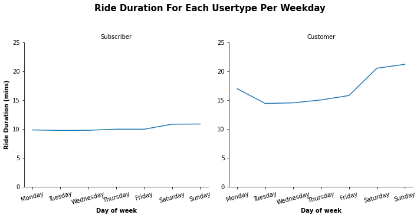